# Geodesic Patterns

for Freeform Architecture

Alan Rynne

September 2018

# 1 Objective

## 1.1 Objective

Discretize a given freeform surface into planks with the following properties:

1. Must be *developable* (Shelden 2002)
2. Should tend to have approximate *equal width*
3. Should be *as straight as possible*
4. Cannot bend by their strong axis but,
5. can have a twist and bend by their weak axis

## 1.2 Objective

**Plank**

A plank is timber that is flat, elongated, and rectangular with parallel faces that are higher and longer than wide. (Wikipedia)

[figure not shown]

Figure 1: Straight planks bent on a hyperbolic paraboloid (a) and a cylindrical surface (b)..

# 2 Background

## 2.1 Background

The use of *straight developable planks* is widely used in:

[figure not shown]

Traditional boat building

## 2.2 Background

Also common practice in naval engineering industry:

[figure not shown]

Connected developable patches for boat hull design

## 2.3 Background

The architecture studio NOX was one of the first to experiment with paper strips.

[figure not shown]

Figure 2: NOX Strips models

[figure not shown]

Figure 3: NOX render of strip model

## 2.4 Background

This techniques have also been used in the architecture world, mainly by **Frank Ghery**.

His façades are usually a collection of connected developable surfaces.

[figure not shown]

Figure 4: Famous Ghery projects (right to left): Guggenheim Museum (Bilbao, 1997), Walt Disney Concert Hall (Los Angeles, 2003) and the Guggenheim Abu Dhabi winning proposal (Abu Dhabi, –).

## 2.5 Background

Latest architectural work following similar techniques was:

[figure not shown]

## 2.6 Background

It was designed as a collection of:

- **Developable surfaces**
  - *Which can be covered by equal width planks*
- **Surfaces of constant curvature**
  - *Which can be covered by repeating the same profile*

[figure not shown]

## 2.7 Background

[figure not shown]

Figure 5: Burj Khalifa final panel solution

## 2.8 Background

Other projects of interest are:

[figure not shown]

Figure 6: Interior view of Toyo Ito’s Mina No Mori wooden lattice roof (a) and exterior view of the lattice under construction (b)..

## 2.9 Background

[figure not shown]

Figure 7: Shigeru Ban’s Yeoju Golf Resort. Right: Interior view of finished roof lattice. Left: Aerial view of lattice under construction..

# 3 Construction technique

## 3.1 Geodesic curves

A geodesic curve is the generalization of a *straight line* into *curved spaces*.

In this research, we concentrate on the concept of *straightest geodesics*.

[figure not shown]

Figure 8: Geodesics on a torus: Although $g_0$ and $g_1$ are both geodesics, one doubles the length of the other

## 3.2 Developable surfaces

[figure not shown]

Figure 9: Surfaces with *0 gaussian curvature*. Meaning, they can be flattened onto a plane *without distortion*

## 3.3 Developable panels

We are interested in:

> **Developable surfaces**
> - surfaces that can be flattened.
> - can be generated by a single curve.

> **Geodesic curves**
> - are straight lines in a curved space.

## 3.4 Developable panels

**If**

Panels are generated using geodesic curves on the surface

**Then**

Resulting panels will be *developable* and mostly *straight* when flat.

[figure not shown]

Figure 10: Straight planks bent on a hyperbolic paraboloid (a) and a cylindrical surface (b)..

## 3.5 Developable panels

**In other words**

We wish to cover a given freeform surface with a pattern of **geodesic curves** with equal spacing.

This can only be achieved if the provided surface is already *developable*.  
A compromise exists between the *curve spacing* and the *curve’s geodesic curvature*

## 3.6 Properties we aim for

**Geodesic property**

Look for *straight* or *as straight as possible* curves.

**Constant width property**

Curves that are *equally spaced* on the surface

**Developable property**

Surfaces generated from the curves *MUST* be developable.

# 4 Algorithmic strategies

## 4.1 Obtaining Geodesic Patterns

These are the main methods for the obtaining successful geodesic patterns:

1. The *parallel transport* method
2. The *evolution* method
   1. The *piecewise geodesic* evolution method
3. The *level-set* method

# 5 The parallel transport method

## 5.1 Vector parallel transport

[figure not shown]

Figure 11: Parallel transport of a vector over a path on a sphere

## 5.2 Vector parallel transport

[figure not shown]

Figure 12: Parallel transport over two adjacent mesh faces

## 5.3 The parallel transport method

[figure not shown]

Figure 13: Parallel transport method over a positive curvature surface

## 5.4 The parallel transport method

[figure not shown]

Figure 14: Parallel transport method diagram

## 5.5 The parallel transport method

## 5.6 The parallel transport method

There are **three** *extreme* cases depending on the *local gaussian curvature* where $g$ lies on $\Phi$:

**Positive curvature**

Panels will have **Maximum width** on $g$

**Negative curvature**

Panels will have **Minimum width** on $g$

**0 gaussian curvature:**

Panels will be of equal width

[figure not shown]

## 5.7 The parallel transport results

[figure not shown]

Figure 15: Parallel transport results over a positive curvature surface. Starting geodesic (red) and geodesic pattern (white). **Máximum** distance between curves occur on $g$.

## 5.8 The parallel transport results

[figure not shown]

Figure 16: Parallel transport results over a negative curvature surface. Starting geodesic $g$ (red) and geodesic pattern (white). **Minimum** distance between panels occur on $g$

## 5.9 The parallel transport results

[figure not shown]

Figure 17: Parallel transport results over a doubly curved surface. Starting geodesic (red) and geodesic pattern (white).

# 6 The Evolution Method

## 6.1 The Evolution Method

[figure not shown]

Figure 18: Calculating the best-fit geodesic

## 6.2 Evolution Implementation

## 6.3 Evolution Method Results

[figure not shown]

Figure 19: Evolution method results over a positive curvature surface. Starting geodesic (red), geodesic pattern (white) and results from fig. 15 (dashed gray lines).

## 6.4 Evolution Method Results

[figure not shown]

Figure 20: Evolution method results over a negative curvature surface. Starting geodesic (red), geodesic pattern (white) and results from fig. 16 (dashed gray lines).

## 6.5 Evolution Method Results

[figure not shown]

Figure 21: Evolution method results over a doubly curved surface. Starting geodesic (red), geodesic pattern (white) and results from fig. 17 (dashed gray lines).

## 6.6 Evolution Method Results

Local changes in curvature produce:

- Sharp panel endings in positive curvature areas
- Panel width increase in negative curvature areas

[figure not shown]

Evolution method example: top view (a), perspective view (b) with highlighted unwanted results.

# 7 The Piecewise Evolution Method

## 7.1 The Piecewise Evolution Method

[figure not shown]

Figure 22: Calculating the best piece-wise geodesic

## 7.2 Piecewise Ev. Implementation

## 7.3 Piecewise Ev. Results

[figure not shown]

## 7.4 Piecewise Ev. Results

[figure not shown]

## 7.5 Piecewise Ev. Results

[figure not shown]

## 7.6 Piecewise Ev. Results

[figure not shown]

Figure 23: Piecewise Test

## 7.7 Piecewise Ev. Results

[figure not shown]

Figure 24: Piecewise Test

# 8 The level set method

## 8.1 Mesh Level-sets

[figure not shown]

Figure 25: Level set on a single mesh face

## 8.2 Level-set Start Condition

[figure not shown]

Figure 26: Starting conditions for the level set method on a double curve surface

## 8.3 Computed level sets

[figure not shown]

Figure 27: Final result of the level set method over a complex double curve surface.

# 9 Piecewise geodesic vector-fields

## 9.1 Piecewise geodesic vector-fields

[figure not shown]

Figure 28: Geodesic pattern example[^1]

## 9.2 Piecewise geodesic vector-fields

The objective is to divide or *cut* the mesh into areas that will be easilly covered by a 1-pattern of geodesics.[^2]

[figure not shown]

Figure 29: User specified directions

[figure not shown]

Figure 30: Computed geodesic vector field & cuts

This is done by computing a *geodesic vector field* over the surface, in a way that it aligns with several user specified directions.

# 10 Modeling planks

## 10.1 Tangent-developable method

Given any point in $g$:

1. Assuming $T(x)$ is tangent $g$.
2. Compute $U(x)$ as $T(x)\times N_\Phi(x)$

> The union of all $U(x)$ is a developable ruled surface $\Psi$.

[figure not shown]

Figure 31: Tangent developable method for panels

## 10.2 Tangent-developable method

Initial algorithm is as follows:

> For all geodesics $s_i$ in a given pattern:
1. Compute the *tangent developable surfaces* $\rightarrow\Psi_i$
2. Trim $\Psi_i$ along the intersection curves with their respective neighbours.
3. Unfold the trimmed $\Psi_i$, obtaining the panels in flat state.

*Unfortunately*, this method needs to be refined in order to work in practice because:

1. The rulings of tangent developable may behave in weird ways
2. The intersection of the neighboring $\Psi_i$’s is often *ill-defined*.

## 10.4 Tangent-developable method

[figure not shown]

Figure 32: Panels computed using the using the modified tangent developable method.

# 11 Analysis

## 11.1 Stress in panels

> **Assuming the material:**
- is bent to the shape of a ruled surface $\Psi$
- the central line $m$ of the plank follows the *‘middle geodesic’* in $\Psi$.

> **Then:**
- Lines parallel to $m$ at distance $d/2$ are not only bent but also stretched.

## 11.2 Stress in panels

If we introduce the radius of Gaussian curvature $\rho = 1 / \sqrt{|K|}$

the relative increment in length $\varepsilon$ (strain) of the strip is:

$$\varepsilon=\frac{1}{2}(d/2\rho)^2+\cdots \qquad(1)$$

### 11.2 Where:

- $d$ is the plank width
- $\rho$ is the radius of gausian curvature

## 11.3 Tensile stress

Tensile stress can be expressed as $\sigma = E\varepsilon$[^3], which yields:

$$\sigma_{max} = \text{maximum admissible stress}$$
$$E = \text {Young's modulus}$$

## 11.4 Admissible panel width

Since $C$ is a material constant. We obtain the maximum admissible width with:

$$d_{max} = 2\rho_{min}C$$

## 11.5 C constant

Example calculation of constant $C$ for some of the most suitable materials.

[output not shown]

## 11.7 Bending and shear stress

> **Only for panels with thin rectangular cross-sections ($h/d \ll 1$)**

Bending ($\sigma$) and shear stresses ($\tau$) depend on:

Panel thickness $h$ but *not* on the panel width $d$.

## 11.8 Temp Title

Maximum values occur on the outer surface of the panel (Wallner et al. 2010) and depend on:

- the curvature $\kappa$ of the central geodesic
- the rate of torsion $\theta$ of the panel.

> $$\sigma = E \kappa h/2 \quad and\quad \tau = hG\theta\qquad(2)$$

Where $G$ is the shear modulus.

## 11.9 Temp Title

maximum value ocurs if:

- the central geodesic’s tangent is an asymptotic direction of the panel surface (Carmo 2016).

## 11.10 Temp Title

It is standard procedure to combine all streses (tension, shear, bending) and use this information for checking panel admissibility.

# 12 Conclusion

## 12.1 Temp Title

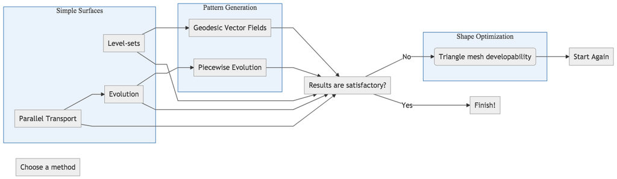

## 12.2 Temp Title

- Parallel transport method is ONLY usefull when surfaces are developable or *nearly* developable.
- Evolution Method improves upon it’s predecessor but still lacks the ability to maintain equal thickness over complex surfaces.
- *Piecewise* evolution method gives the best results overall.
- *Level-set method* can be used to calculate geodesic webs.
  - To cover freeform surfaces it need to be coupled with the geodesic-vector field technique.
- *Geodesic vector fields* is an introductory step to cut the mesh into pieces that will be easily covered by a 1-pattern of geodesic curves.
- *Developalizing* the surface is an extreme measure, since during the process, the overall smoothness of the surface will be lost. It can still be done in a controlled manner to reduce areas of high curvature.

# 13 Thanks[^4]

# 14 Appendix

## References

Carmo, Manfredo P do. 2016. *Differential Geometry of Curves and Surfaces: Revised and Updated Second Edition*. Courier Dover Publications.

Pottmann, Helmut, Qixing Huang, Bailin Deng, Alexander Schiftner, Martin Kilian, Leonidas Guibas, and Johannes Wallner. 2010. “Geodesic Patterns.” In *ACM SIGGRAPH 2010 Papers on - SIGGRAPH ’10*. https://doi.org/10.1145/1833349.1778780.

Shelden, Dennis Robert. 2002. “Digital Surface Representation and the Constructibility of Gehry’s Architecture.” PhD thesis, Massachusetts Institute of Technology. http://hdl.handle.net/1721.1/16899.

Wallner, Johannes, Alexander Schiftner, Martin Kilian, Simon Flöry, Mathias Höbinger, Bailin Deng, Qixing Huang, and Helmut Pottmann. 2010. “Tiling Freeform Shapes with Straight Panels: Algorithmic Methods.” In *Advances in Architectural Geometry 2010*, edited by Cristiano Ceccato, Lars Hesselgren, Mark Pauly, Helmut Pottmann, and Johannes Wallner. Vienna: Springer Vienna. https://doi.org/10.1007/978-3-7091-0309-8_5.